# Lab 5: Sampling Distributions

Daniel Deneau

2021-06-19

```r
library(tidyverse)
library(openintro)
download.file("http://www.openintro.org/stat/data/ames.RData", destfile = "ames.RData")
load("ames.RData")
```

### Exercise 1

```r
area <- ames$Gr.Liv.Area
price <- ames$SalePrice
summary(area)
```

```
##    Min. 1st Qu.  Median    Mean 3rd Qu.    Max.
##     334    1126    1442    1500    1743    5642
```

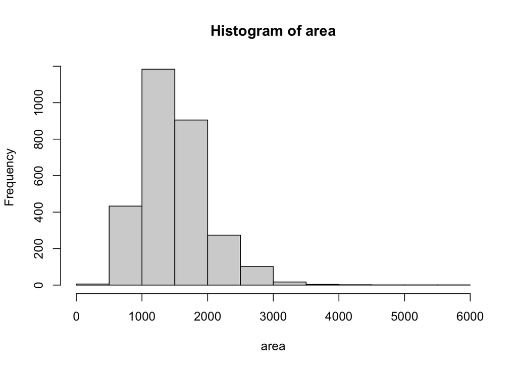

```r
hist(area, breaks = 14)
```

### Exercise 2

```r
samp1 <- sample(area, 50)

summary(samp1)
```

```
##    Min. 1st Qu.  Median    Mean 3rd Qu.    Max.
##     672    1072    1406    1571    1974    3279
```

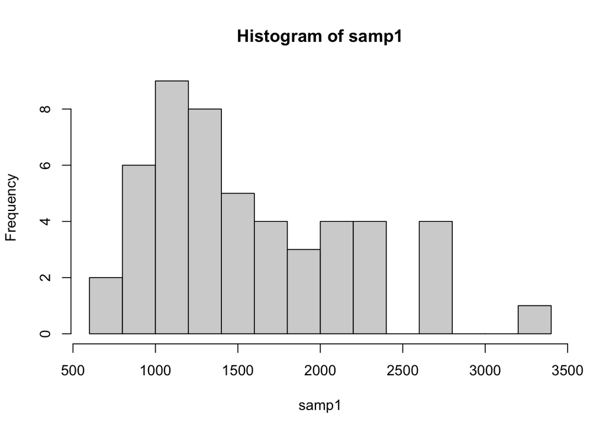

```r
hist(samp1, breaks = 14)
```

### Exercise 3

```r
samp2 <- sample(area, 50)

mean(samp1)
```

```
## [1] 1570.86
```

```r
mean(samp2)
```

```
## [1] 1513.2
```

### Excercise 4

The sample_means50 variable contains 5000 elements. The distribution of the means within sample_means50 is unimodal and symmetric with a center around 1500. With 50,000 samples, I would expect the distribution to be very similar similar shape and summary values, but with less error in the mean from the population mean.

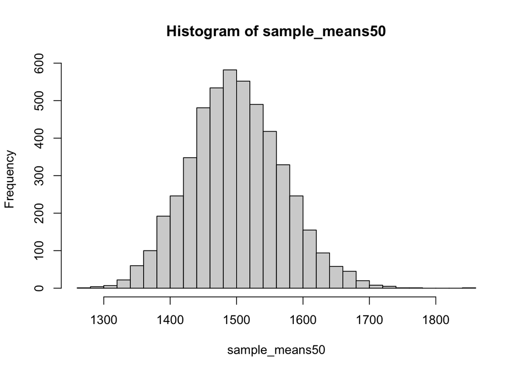

```r
sample_means50 <- rep(NA, 5000)

for(i in 1:5000){
   samp <- sample(area, 50)
   sample_means50[i] <- mean(samp)
}

hist(sample_means50, breaks = 25)
```

```r
summary(sample_means50)
```

```
##    Min. 1st Qu.  Median    Mean 3rd Qu.    Max.
##    1269    1452    1497    1500    1545    1857
```

### Excercise 5

Each of the 100 elements in sample_means_small represents the average area from one of the 100 randoms samples of size 50 that were taken of area variable inside the for-loop.

```r
sample_means_small <- rep(0, 100)

for(i in 1:100){
  samp <- sample(area, 50)
  sample_means_small[i] <- mean(samp)
}

sample_means_small
```

```
##   [1] 1546.28 1429.16 1434.70 1568.90 1504.16 1556.60 1661.28 1580.88 1583.44
##  [10] 1547.70 1532.36 1539.12 1409.80 1523.22 1447.94 1447.82 1487.44 1458.64
##  [19] 1414.78 1466.32 1488.22 1347.92 1399.30 1565.24 1662.80 1360.26 1443.70
##  [28] 1611.74 1528.56 1577.16 1465.30 1483.18 1480.10 1395.72 1595.88 1488.82
##  [37] 1518.68 1406.06 1504.58 1519.84 1441.00 1619.14 1568.16 1468.76 1494.28
##  [46] 1571.04 1613.80 1515.06 1497.12 1510.40 1523.04 1530.44 1455.08 1591.70
##  [55] 1564.66 1601.58 1477.96 1506.46 1445.86 1482.80 1411.98 1467.42 1624.16
##  [64] 1416.58 1539.74 1504.04 1441.06 1474.90 1507.92 1438.02 1609.30 1526.36
##  [73] 1571.98 1518.76 1546.66 1457.06 1473.84 1405.24 1583.98 1496.66 1414.26
##  [82] 1319.16 1447.74 1430.56 1486.82 1483.34 1592.84 1423.86 1483.02 1544.30
##  [91] 1407.74 1546.90 1463.82 1579.52 1511.58 1648.64 1564.04 1551.64 1467.14
## [100] 1569.26
```

### Excercise 6

As the sample size increases, it is clear that the center of the distribution becomes much more defined near the true population proportion. The spread of the distributions also decreases as the sample size increases. With more samples, there is less standard error so it makes sense that each of the observations are tighter to the center.

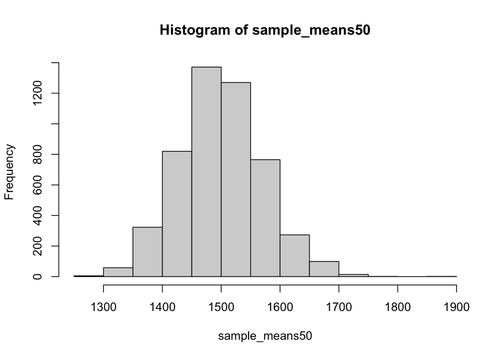

```r
hist(sample_means50)
```

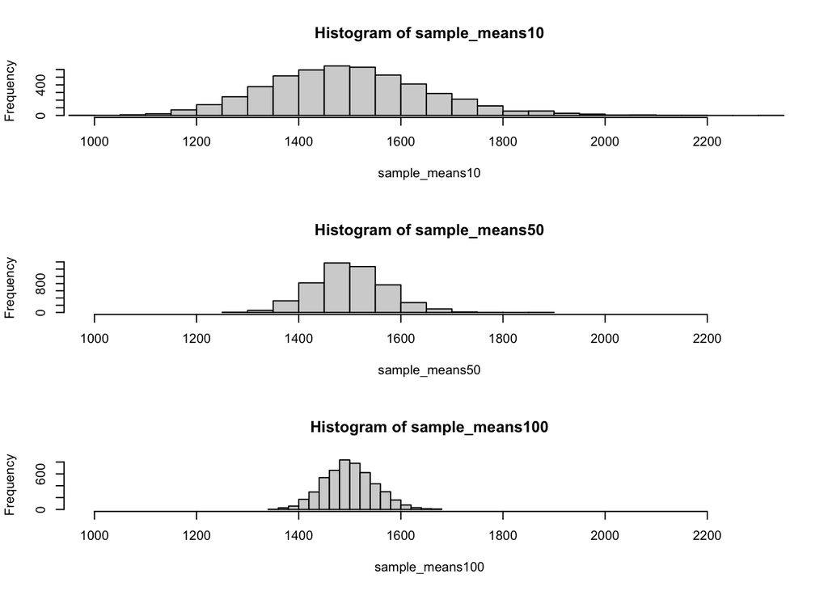

```r
sample_means10 <- rep(NA, 5000)
sample_means100 <- rep(NA, 5000)

for(i in 1:5000){
  samp <- sample(area, 10)
  sample_means10[i] <- mean(samp)
  samp <- sample(area, 100)
  sample_means100[i] <- mean(samp)
}

par(mfrow = c(3, 1))

xlimits <- range(sample_means10)

hist(sample_means10, breaks = 20, xlim = xlimits)
hist(sample_means50, breaks = 20, xlim = xlimits)
hist(sample_means100, breaks = 20, xlim = xlimits)
```

### On Your Own 1

```r
sample_price <- sample(price, 50)
summary(sample_price)
```

```
##    Min. 1st Qu.  Median    Mean 3rd Qu.    Max.
##   78000  128700  142500  164735  188750  372397
```

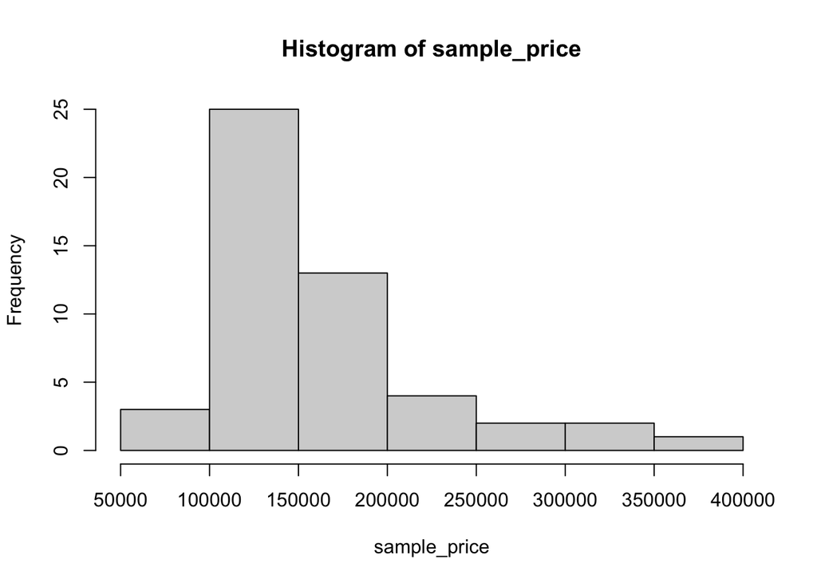

```r
hist(sample_price)
```

### On Your Own 2

The shape of the distribution is unimodal and symmetric with an average-to-small spread and a few outliers. Based on this, I would expect the mean home price to be $181,000.00

Calculated: $180,796.10

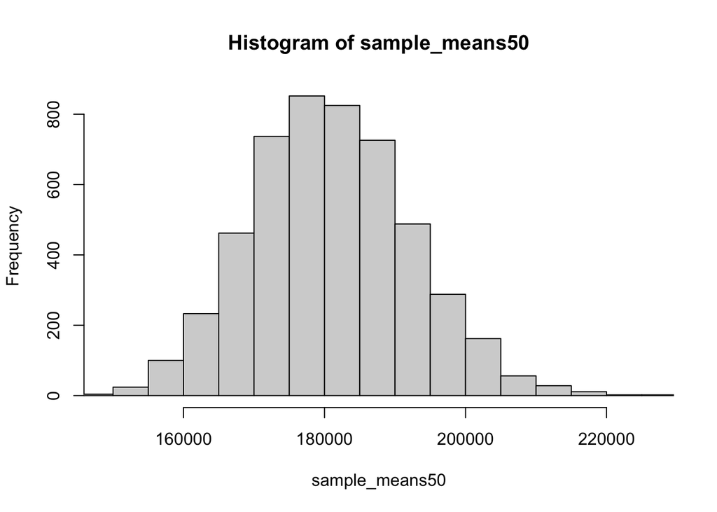

```r
sample_means50 <- rep(NA, 5000)

for(i in 1:5000){
  samp = sample(price, 50)
  sample_means50[i] = mean(samp)
}

hist(sample_means50, breaks = 20, xlim = range(sample_means50))
```

```r
mean(price)
```

```
## [1] 180796.1
```

### On Your Own 3

The distribution for a sample size of 150 is very similar to the last one. With a slightly tighter spread, and a more defined center near $180,000. Based on this, I would guess the mean sale price of homes in Ames to be $180,000.00

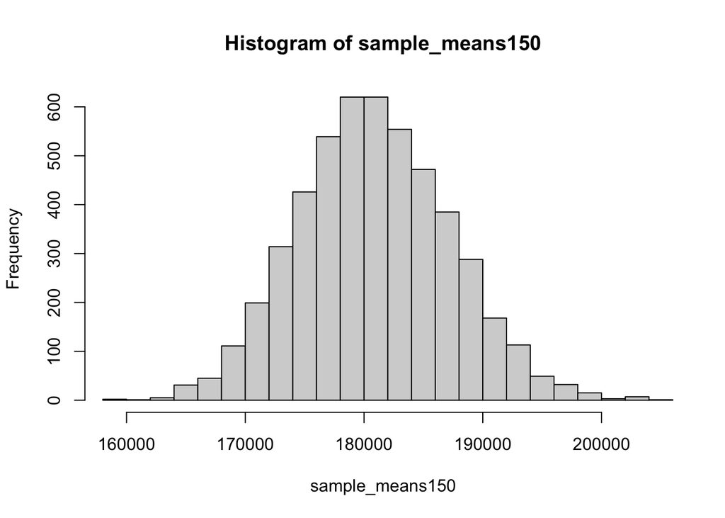

```r
sample_means150 <- rep(NA, 5000)

for(i in 1:5000){
  samp = sample(price, 150)
  sample_means150[i] = mean(samp)
}

hist(sample_means150, breaks = 20, xlim = range(sample_means150))
```

### On Your Own 4

The distribution in problem 3 had a smaller spread. When making estimates closest to population values, it would be best to have the smallest spread possible, as that decreases the range of unlikely possibilities being estimated.In problem 3, with less spread. It was easier to esimate a value closer to the calculated population mean.

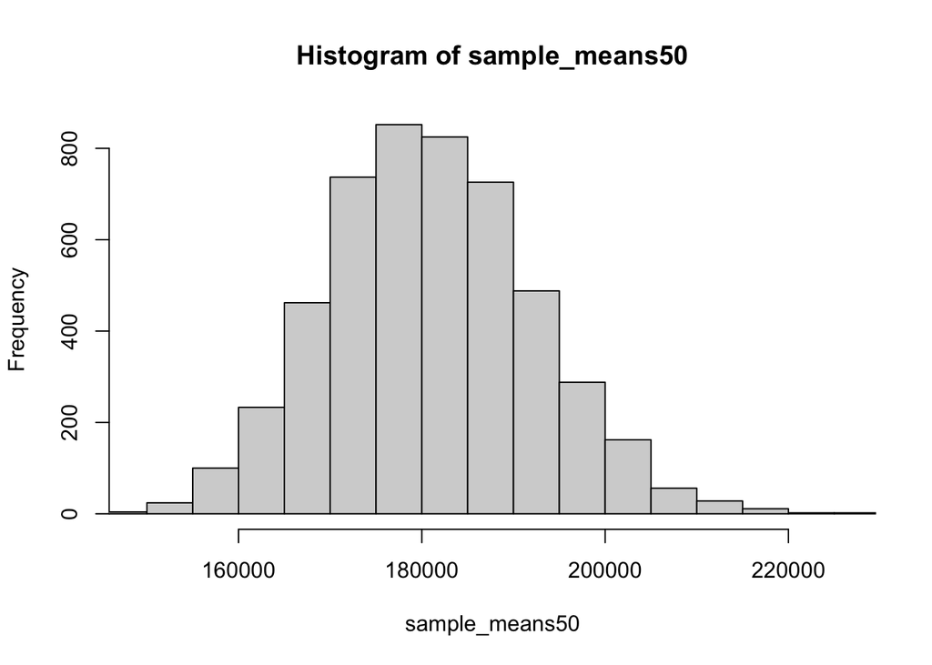

```r
hist(sample_means50, breaks = 20, xlim = range(sample_means50))
```

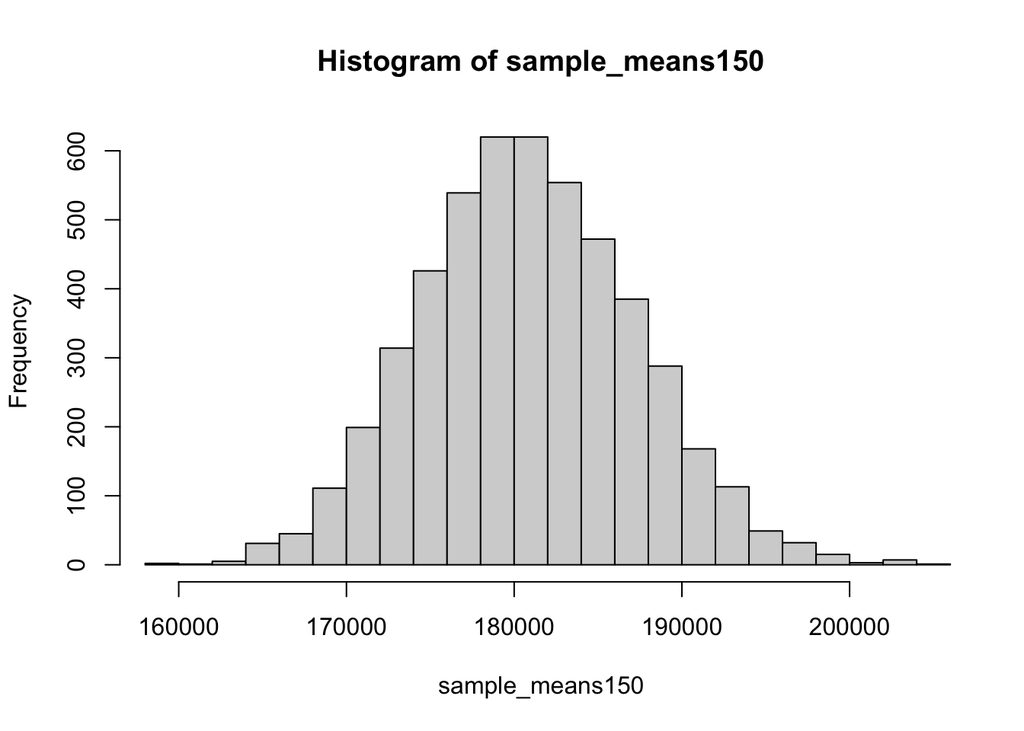

```r
hist(sample_means150, breaks = 20, xlim = range(sample_means150))
```

```r
mean(price)
```

```
## [1] 180796.1
```

```r
mean(sample_means150)
```

```
## [1] 180865.8
```

```r
mean(sample_means50)
```

```
## [1] 180956
```